# Preprocessing, clustering and classification of tweets in R

## 11.4 Dot Plots

These are useful plots as the show both the mean estimated accuracy as well as the 95% confidence interval. They are useful to compare the means and the overlap of the spreads between algorithms. We can compare algorithms like we did with the boxplot.

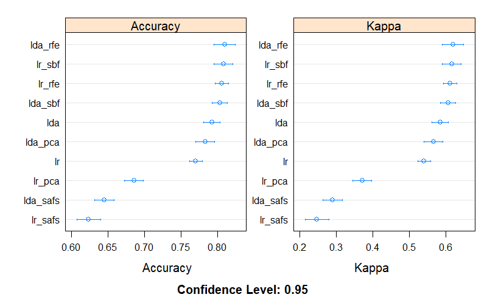

```r
scales <- list(x=list(relation="free"), y=list(relation="free"))
dotplot(resamps, scales=scales)
```

## 11.5 Scatterplot Matrix

This creates a scatterplot matrix of all results for an algorithm compared to the results for all other algorithms. These are useful to compare pairs of algorithms.

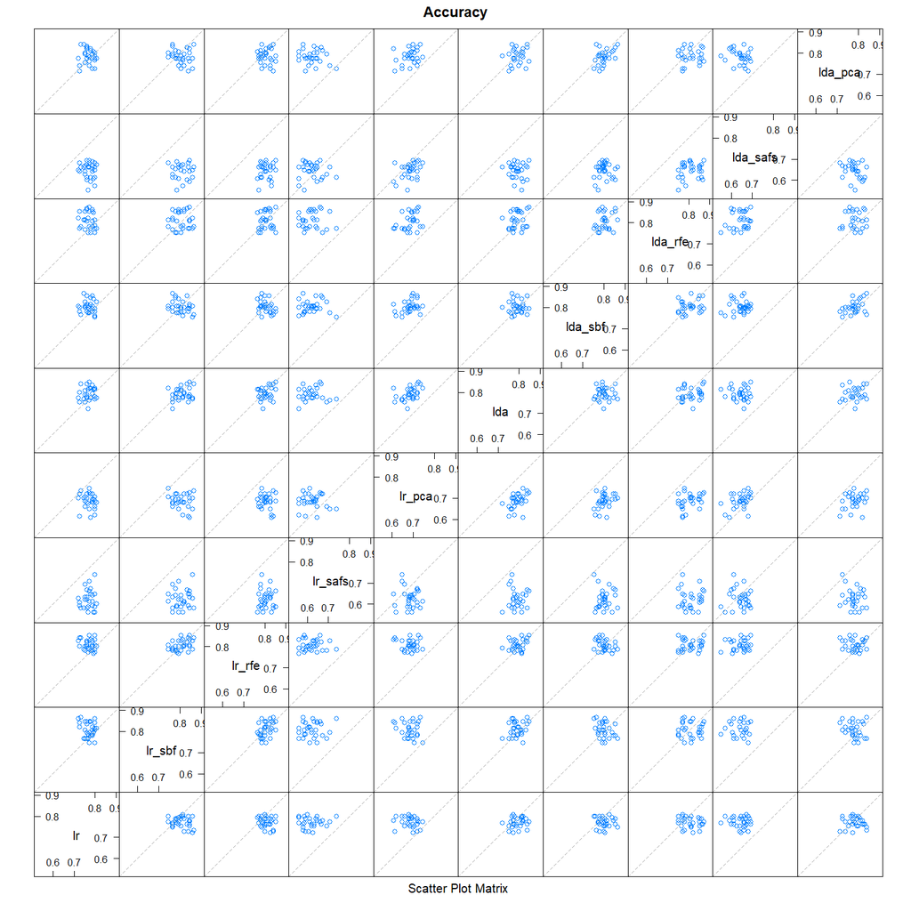

```r
splom(resamps)
```

## 11.6 Pairwise xyPlots

We can zoom in on one pair-wise comparison of the accuracy for two algorithms with an xyplot. For example, we can compare the two main algorithms to see that LDA is better than LR.

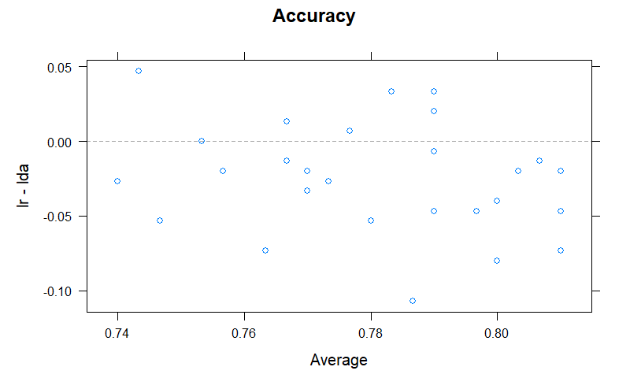

```r
xyplot(resamps, what = "BlandAltman", models = c("lr", "lda"))
```

Another useful comparison is to check the effect of feature selection and extraction. For the Logistic Regression algorithm, Univariate Filters and Recursive Feature Elimination improve the accuracy. However, Simulated Annealing and Principal Component Analysis get worse results.

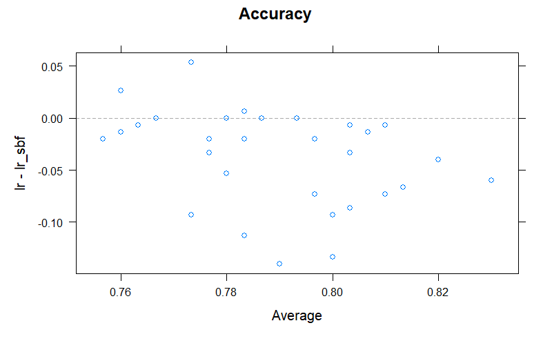

```r
xyplot(resamps, what = "BlandAltman", models = c("lr", "lr_sbf"))
```

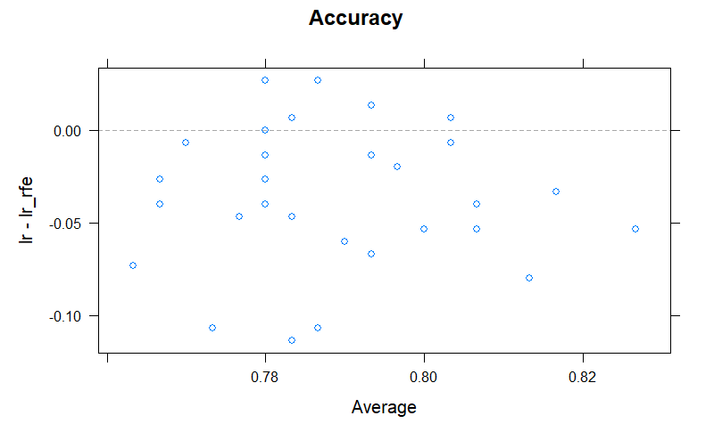

```r
xyplot(resamps, what = "BlandAltman", models = c("lr", "lr_rfe"))
```

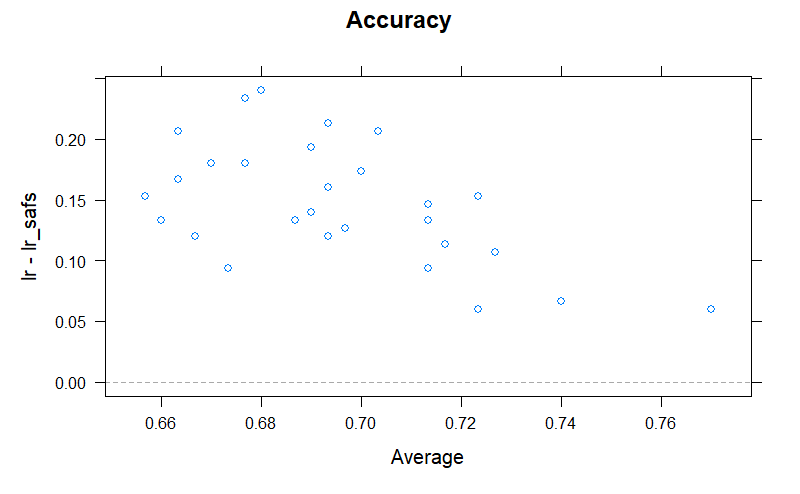

```r
xyplot(resamps, what = "BlandAltman", models = c("lr", "lr_safs"))
```

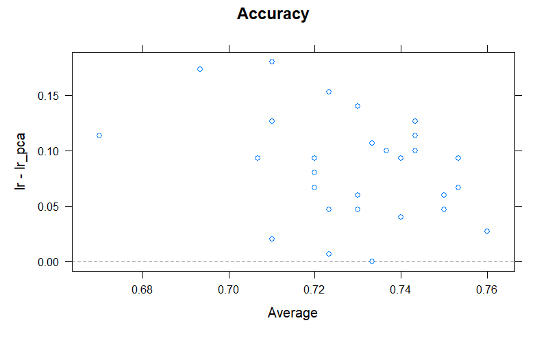

```r
xyplot(resamps, what = "BlandAltman", models = c("lr", "lr_pca"))
```

## 11.7 Statistical Significance Tests

Note than in our case, due to the 3 repetitions of the 10-fold cross-validation process, there are 30 resampling results for each classifier. The same paired cross-validation subsets of samples were used for all classifiers. We have to use a paired t-test to calculate the significance of the differences between both classifiers.

Using the `diff` function over the `resamps` object calculates the differences between all pairs of classifiers. The output shows, for each metric (accuracy and kappa), the difference of the mean (positive or negative) between both classifiers. The p-value of the whole t-test is 0, which indicates that there is a significant difference between some classifiers. Therefore, we can discard the null hypothesis that says that there is no difference between classifiers.

The interpretation of the p-value is the key point. It is related with the risk of erroneously discarding the null-hypothesis of similarity between compared classifiers, when there is no real difference. Roughly speaking, it can also be interpreted as the degree of similarity between both classifiers. A p-value smaller than 0.05 alerts about statistically significant differences between both classifiers. That is, when the risk of erroneously discarding the hypothesis of similarity between both classifiers is low, we assume that there is a statistically significant difference between classifiers.

The lower diagonal of the table shows p-values for the null hypothesis. The upper diagonal of the table shows the estimated difference between the distributions. We can see that is come cases the p-value is bigger than 0.05 and therefore we can not discard the null hypothesis. In some other cases, the p-value is smaller than 0.05 so we can surely discard the null hypothesis.

```r
diffs <- diff(resamps)
summary(diffs)
```

```
Call:
summary.diff.resamples(object = diffs)

p-value adjustment: bonferroni
Upper diagonal: estimates of the difference
Lower diagonal: p-value for H0: difference = 0

Accuracy
         lr        lr_sbf    lr_rfe    lr_safs   lr_pca    lda       lda_sbf
lr                 -0.037778 -0.035778  0.146889  0.084889 -0.022000 -0.032667
lr_sbf   0.0056665            0.002000  0.184667  0.122667  0.015778  0.005111
lr_rfe   0.0005784 1.0000000            0.182667  0.120667  0.013778  0.003111
lr_safs  6.967e-15 3.491e-16 < 2.2e-16           -0.062000 -0.168889 -0.179556
lr_pca   1.892e-09 1.372e-11 4.566e-13 0.0001458           -0.106889 -0.117556
lda      0.1057663 1.0000000 1.0000000 3.965e-15 3.230e-15           -0.010667
lda_sbf  0.0034098 1.0000000 1.0000000 6.978e-16 2.278e-15 1.0000000
lda_rfe  0.0088474 1.0000000 1.0000000 2.379e-15 9.486e-14 1.0000000 1.0000000
lda_safs 1.204e-13 2.051e-15 < 2.2e-16 1.0000000 0.0002075 6.769e-15 < 2.2e-16
lda_pca  1.0000000 0.5988760 0.3064779 6.841e-13 3.971e-12 1.0000000 0.1333848
         lda_rfe   lda_safs  lda_pca
lr       -0.039333  0.125333 -0.012667
lr_sbf   -0.001556  0.163111  0.025111
lr_rfe   -0.003556  0.161111  0.023111
lr_safs  -0.186222 -0.021556 -0.159556
lr_pca   -0.124222  0.040444 -0.097556
lda      -0.017333  0.147333  0.009333
lda_sbf  -0.006667  0.158000  0.020000
lda_rfe             0.164667  0.026667
lda_safs 3.805e-16           -0.138000
lda_pca  0.3630450 1.123e-12

Kappa
         lr        lr_sbf    lr_rfe    lr_safs   lr_pca    lda       lda_sbf
lr                 -0.075556 -0.071556  0.293778  0.169778 -0.044000 -0.065333
lr_sbf   0.0056665            0.004000  0.369333  0.245333  0.031556  0.010222
lr_rfe   0.0005784 1.0000000            0.365333  0.241333  0.027556  0.006222
lr_safs  6.967e-15 3.491e-16 < 2.2e-16           -0.124000 -0.337778 -0.359111
lr_pca   1.892e-09 1.372e-11 4.566e-13 0.0001458           -0.213778 -0.235111
lda      0.1057663 1.0000000 1.0000000 3.965e-15 3.230e-15           -0.021333
lda_sbf  0.0034098 1.0000000 1.0000000 6.978e-16 2.278e-15 1.0000000
lda_rfe  0.0088474 1.0000000 1.0000000 2.379e-15 9.486e-14 1.0000000 1.0000000
lda_safs 1.204e-13 2.051e-15 < 2.2e-16 1.0000000 0.0002075 6.769e-15 < 2.2e-16
lda_pca  1.0000000 0.5988760 0.3064779 6.841e-13 3.971e-12 1.0000000 0.1333848
         lda_rfe   lda_safs  lda_pca
lr       -0.078667  0.250667 -0.025333
lr_sbf   -0.003111  0.326222  0.050222
lr_rfe   -0.007111  0.322222  0.046222
lr_safs  -0.372444 -0.043111 -0.319111
lr_pca   -0.248444  0.080889 -0.195111
lda      -0.034667  0.294667  0.018667
lda_sbf  -0.013333  0.316000  0.040000
lda_rfe             0.329333  0.053333
lda_safs 3.805e-16           -0.276000
lda_pca  0.3630450 1.123e-12
```

# 12 Bibliography

[1] Ingo Feinerer. tm: Text Mining Package, 2012. R package version 0.5-7.1.

[2] Ingo Feinerer, Kurt Hornik, and David Meyer. Text mining infrastructure in R. Journal of Statistical Software, 25(5):1-54, 3 2008.

[3] Ian Fellows. wordcloud: Word Clouds, 2014. R package version 2.5.

[4] M. Kuhn and K. Johnson. Applied Predictive Modeling. Springer, 2013.

[5] Max Kuhn. Contributions from Jed Wing, Steve Weston, Andre Williams, Chris Keefer, Allan Engelhardt, Tony Cooper, Zachary Mayer, and the R Core Team. caret: Classification and Regression Training, 2014. R package version 6.0-35.